# Biostatistical Computing, PHC 6068

Linear Model

Zhiguang Huo (Caleb)

Monday October 14, 2019

# Outlines

- Linear regression
- Model diagnositic
- Model selection
- non linear fitting

# linear regression model (population version)

- $Y \in \mathbb{R}$, $X_j \in \mathbb{R}$ with $j = \{1, \ldots, p\}$, $\beta_j \in \mathbb{R}$ with $j = \{0, \ldots, p\}$, $\varepsilon \in \mathbb{R}$

$$Y = \beta_0 + \beta_1X_1 + \beta_2X_2 + \ldots + \beta_pX_p + \varepsilon, \text{with }\varepsilon \sim N(0, \sigma^2)$$

- Y: outcome variable, response, or dependent variable.
- $X_1, X_2, \ldots, X_p$ are called predictors, or independent variables.
- $\beta_0, \beta_1, \ldots, \beta_p$ are called coefficients, for which we will estimate.

Assumptions:

- $Y$ is a linear combination of $X_1, X_2, \ldots, X_p$.
- $\varepsilon \sim N(0, \sigma^2)$.

# linear regression model (sample version)

- $Y = (Y_1, \ldots, Y_n)^\top \in \mathbb{R}^n$
- $X = (1_n, X_1, \ldots, X_p) \in \mathbb{R}^{n \times (p+1)}$
  - $1_n \in \mathbb{R}^n$,
  - $X_j \in \mathbb{R}^n$ with $1 \le j \le p$
- $\beta = (\beta_0, \beta_1, \ldots, \beta_p)^\top \in \mathbb{R}^{p+1}$
- $\varepsilon = (\varepsilon_1, \ldots, \varepsilon_n)^\top \in \mathbb{R}^n$

$$Y = X\beta + \varepsilon$$

Assumptions:

- $Y$ is a linear combination of $1_n, X_1, X_2, \ldots, X_p$.
- $\varepsilon_i \sim N(0, \sigma^2)$.
- $\varepsilon_i$’s are independently identically distributed (iid).

# Solution to linear regression model

- least square estimator (LS):
  $$\hat{\beta} = \arg \min_\beta \frac{1}{2}\| Y - X\beta\|_2^2$$
  - $\|a\|_2 = \sqrt{a_1^2 + \ldots + a_p^2}$.
- Maximum likelihood estimator (MLE):
  $$\hat{\beta} = \arg \max_\beta L(\beta; X, Y)$$
- For linear regression model, LS estimator is the same as MLE
  $$\hat{\beta} = (X^\top X)^{-1} X^\top Y$$
  Assuming $X^\top X$ is invertable

# Fit linear model in R, lm()

Basic syntax for lm()

```r
lm(formula, data)
```

- formula: Symbolic description of the model
- data: Optional dataframe containing the variables in the model
- summary() function summarize the linear model result
- plot() function output model diagnostic results

```r
lmfit <- lm(mpg ~ cyl, data=mtcars)
lmfit
```

```
##
## Call:
## lm(formula = mpg ~ cyl, data = mtcars)
##
## Coefficients:
## (Intercept)          cyl
##      37.885       -2.876
```

```r
summary(lmfit)
```

```
##
## Call:
## lm(formula = mpg ~ cyl, data = mtcars)
##
## Residuals:
##     Min      1Q  Median      3Q     Max
## -4.9814 -2.1185  0.2217  1.0717  7.5186
##
## Coefficients:
##             Estimate Std. Error t value Pr(>|t|)
## (Intercept)  37.8846     2.0738   18.27  < 2e-16 ***
## cyl          -2.8758     0.3224   -8.92 6.11e-10 ***
## ---
## Signif. codes:  0 '***' 0.001 '**' 0.01 '*' 0.05 '.' 0.1 ' ' 1
##
## Residual standard error: 3.206 on 30 degrees of freedom
## Multiple R-squared:  0.7262, Adjusted R-squared:  0.7171
## F-statistic: 79.56 on 1 and 30 DF,  p-value: 6.113e-10
```

- Interpretation:
  - Unit increase in cyl will result in 2.88 decrease in mpg.
  - p-value of cyl < 0.05 indicates cyl is a significant predictor.

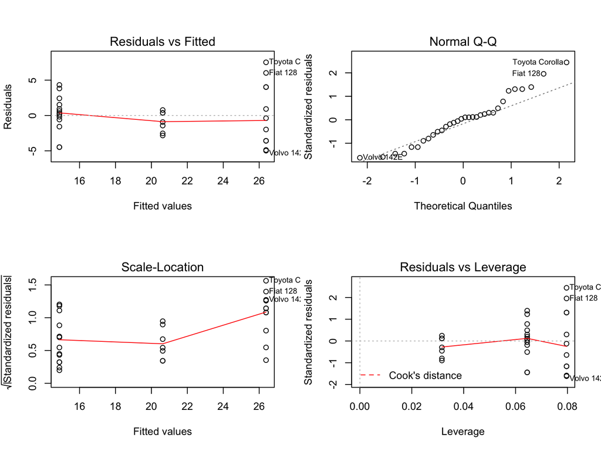

```r
par(mfrow=c(2,2))
plot(lmfit)
```

# Prostate cancer data

The data is from the book element of statistical learning

```r
library(ElemStatLearn)
str(prostate)
```

```
## 'data.frame':    97 obs. of  10 variables:
##  $ lcavol : num  -0.58 -0.994 -0.511 -1.204 0.751 ...
##  $ lweight: num  2.77 3.32 2.69 3.28 3.43 ...
##  $ age    : int  50 58 74 58 62 50 64 58 47 63 ...
##  $ lbph   : num  -1.39 -1.39 -1.39 -1.39 -1.39 ...
##  $ svi    : int  0 0 0 0 0 0 0 0 0 0 ...
##  $ lcp    : num  -1.39 -1.39 -1.39 -1.39 -1.39 ...
##  $ gleason: int  6 6 7 6 6 6 6 6 6 6 ...
##  $ pgg45  : int  0 0 20 0 0 0 0 0 0 0 ...
##  $ lpsa   : num  -0.431 -0.163 -0.163 -0.163 0.372 ...
##  $ train  : logi  TRUE TRUE TRUE TRUE TRUE TRUE ...
```

```r
prostate$train <- NULL
```

Explanation of these variables:

- lpsa: log PSA score
- lcavol: log cancer volume
- lweight: log prostate weight
- age: age
- lbph: log of the amount of benign prostatic hyperplasia
- svi: seminal vesicle invasion
- lcp: log of capsular penetration
- gleason: Gleason score
- pgg45: percent of Gleason scores 4 or 5.
- train: a logical vector indicating training data or testing data (ignore at this moment)

```r
head(prostate)
```

```
##       lcavol  lweight age      lbph svi       lcp gleason pgg45       lpsa
## 1 -0.5798185 2.769459  50 -1.386294   0 -1.386294       6     0 -0.4307829
## 2 -0.9942523 3.319626  58 -1.386294   0 -1.386294       6     0 -0.1625189
## 3 -0.5108256 2.691243  74 -1.386294   0 -1.386294       7    20 -0.1625189
## 4 -1.2039728 3.282789  58 -1.386294   0 -1.386294       6     0 -0.1625189
## 5  0.7514161 3.432373  62 -1.386294   0 -1.386294       6     0  0.3715636
## 6 -1.0498221 3.228826  50 -1.386294   0 -1.386294       6     0  0.7654678
```

# Exploratory analysis

- Distribution of each varaible.
- Correlation between each pair of vairables.
- Visualizing the scattered plot of each pair of variables.

# Distribution of each varaible – Histogram

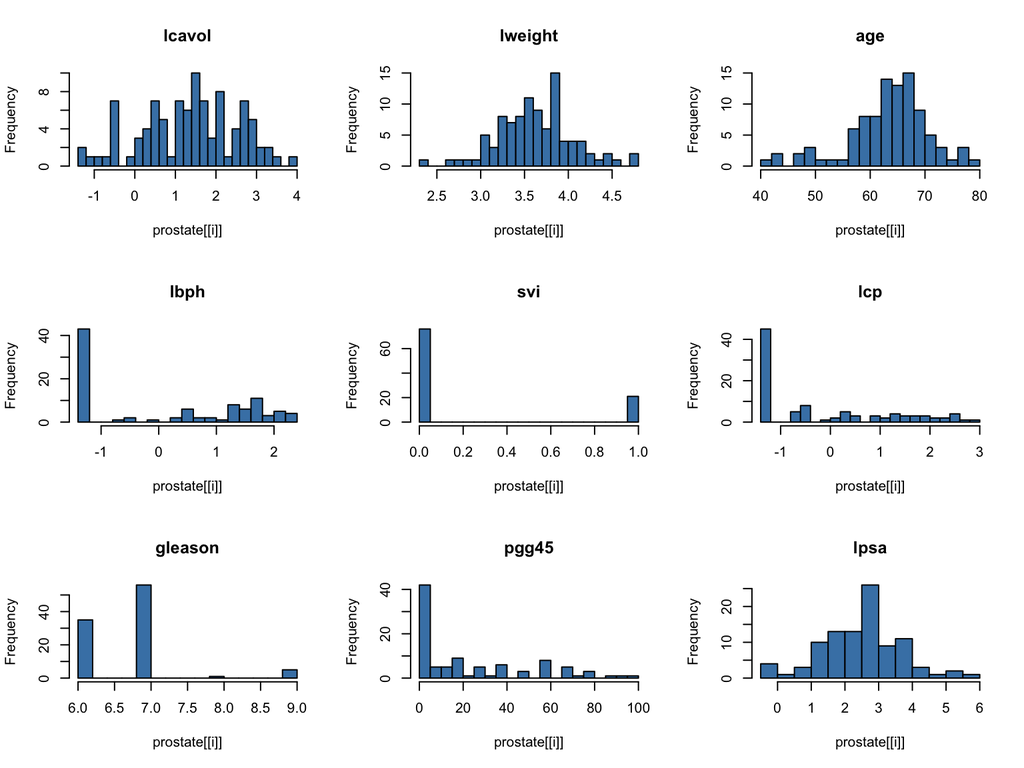

```r
par(mfrow=c(3,3))
for(i in 1:9){
  aname <- names(prostate)[i]
  hist(prostate[[i]], main=aname, col="steelblue", breaks=20)
}
```

What can we learn from the histogram.

- lcp, the log amount of capsular penetration, is very skewed, a bunch of men with little, then a big spread
- svi (the presence of seminal vesicle invasion) is binary
- gleason score, takes integer values of 6 and larger;
- lspa, the log PSA score, is likely to be normally distributed

# Correlation between each pairs of variables

```r
cor_prostate <- cor(prostate)
max(cor_prostate[cor_prostate!=1])
```

```
## [1] 0.7519045
```

```r
maxID <- arrayInd(which(max(cor_prostate[cor_prostate!=1]) == cor_prostate)[1], dim(cor_prostate))
names(prostate)[maxID]
```

```
## [1] "pgg45"   "gleason"
```

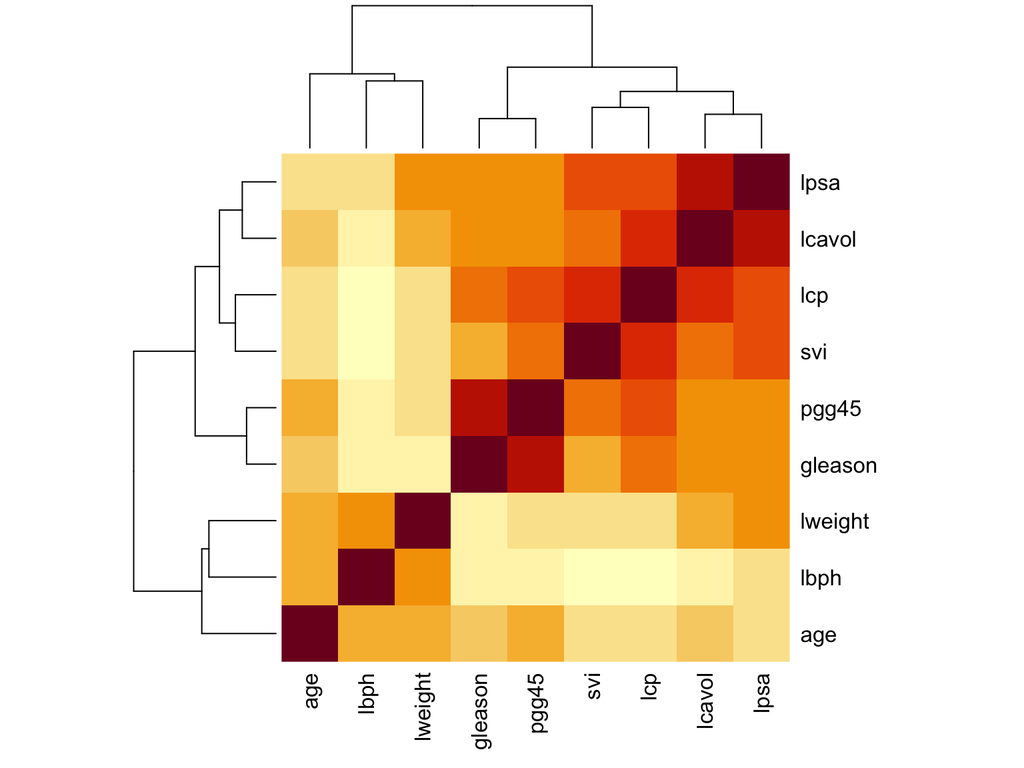

```r
heatmap(cor_prostate, scale="none") ## instead of image. Rowv = F, Colv = F to suppress hierarchical clusteirng dendrogram
```

# visualizing the scattered plot of each pair of variables.

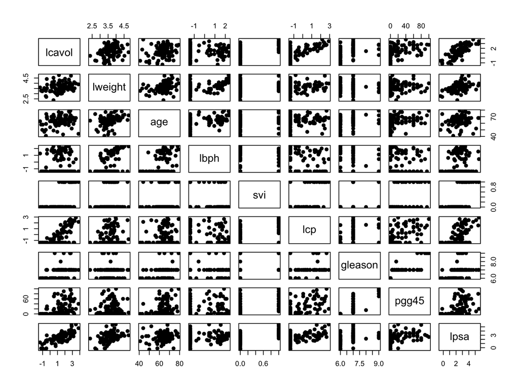

```r
pairs(prostate,pch=19)
```

# Formulas

- Basic form of a formula:
  - response ~ model
- Formula notation:

| Syntax | function |
| --- | --- |
| + | Separate main effects |
| : | Denote interactions |
| * | main effects and interactions |
| ˆn | include all main effects and n-order interactions |
| - | remove the specified terms |
| I() | Brackets the portions of a formula where operators are used mathematically |
| . | Main effect for each column in the dataframe, except the response |

# Fit linear regression model

```r
lm_prostate <- lm(lpsa ~ age + lweight, data = prostate)
lm_prostate
```

```
##
## Call:
## lm(formula = lpsa ~ age + lweight, data = prostate)
##
## Coefficients:
## (Intercept)          age      lweight
##   -1.897709     0.003318     1.147487
```

```r
class(lm_prostate)
```

```
## [1] "lm"
```

```r
names(lm_prostate)
```

```
##  [1] "coefficients"  "residuals"     "effects"       "rank"
##  [5] "fitted.values" "assign"        "qr"            "df.residual"
##  [9] "xlevels"       "call"          "terms"         "model"
```

# Inference for Linear Models

| function | application |
| --- | --- |
| summary() | summary of linear model |
| coef() | get coefficient |
| confint() | Confidence intervals for model parameters |
| predict() | make a prediction |
| fitted() | get fitted value, (e.g., $X\hat{\beta}$) |

```r
summary(lm_prostate)
```

```
##
## Call:
## lm(formula = lpsa ~ age + lweight, data = prostate)
##
## Residuals:
##     Min      1Q  Median      3Q     Max
## -2.2665 -0.6753 -0.0361  0.5317  2.9712
##
## Coefficients:
##              Estimate Std. Error t value Pr(>|t|)
## (Intercept) -1.897709   1.119033  -1.696   0.0932 .
## age          0.003318   0.015369   0.216   0.8295
## lweight      1.147487   0.267094   4.296 4.23e-05 ***
## ---
## Signif. codes:  0 '***' 0.001 '**' 0.01 '*' 0.05 '.' 0.1 ' ' 1
##
## Residual standard error: 1.051 on 94 degrees of freedom
## Multiple R-squared:  0.1882, Adjusted R-squared:  0.1709
## F-statistic: 10.89 on 2 and 94 DF,  p-value: 5.558e-05
```

```r
coef(lm_prostate)
```

```
##  (Intercept)          age      lweight
## -1.897708604  0.003318361  1.147487156
```

```r
confint(lm_prostate)
```

```
##                   2.5 %    97.5 %
## (Intercept) -4.11957499 0.3241578
## age         -0.02719768 0.0338344
## lweight      0.61716615 1.6778082
```

```r
anew <- data.frame(age = 29, lweight = 100)
predict(lm_prostate, anew)
```

```
##        1
## 112.9472
```

```r
head(fitted(lm_prostate))
```

```
##        1        2        3        4        5        6
## 1.446128 2.103985 1.436017 2.061715 2.246634 1.973246
```

# Formulas (continue)

- Sample formulas, for a model with response y and predictors a, b and c

| Model | Interpretation |
| --- | --- |
| y ~ 1 | Just the intercept |
| y ~ a | One main effect |
| y ~ - 1 + a | No intercept |
| y ~ a+b+c+a:b | Three main effects and an interaction between a and b |
| y ~ a * b | All main effects and interactions (same as a+b+a:b) |
| y ~ factor(a) | Create dummy variables for a (if not already a factor) |
| y ~ (a+b+c)ˆ2 | All main effects and second-order interactions |
| y ~ (a+b+c)ˆ2 - a:b | All main effects and second-order interactions except a:b |
| y ~ I(aˆ2) | Transform a to aˆ2 |
| log(y) ~ a | Transform y to log(y) |
| y ~ a/b/c | Factor c nested within factor b within factor a |
| y ~ . | Main effect for each column in the dataframe |

# Demonstrate other formula of lm using prostate cancer data

```r
lm(lpsa ~ 1, data = prostate)
lm(lpsa ~ age, data = prostate)
lm(lpsa ~ - 1 + age, data = prostate)
lm(lpsa ~ age + lweight + gleason + gleason:lweight, data = prostate)
lm(lpsa ~ gleason*lweight, data = prostate)
lm(lpsa ~ factor(gleason), data = prostate)
lm(lpsa ~ (age + lweight + gleason)^2, data = prostate)
lm(lpsa ~ (age + lweight + gleason)^2 - gleason:lweight, data = prostate)
lm(lpsa ~ I(age^2), data = prostate)
lm(log(age) ~ lpsa, data = prostate)
lm(lpsa ~ ., data = prostate)
lm(lpsa ~ as.factor(svi)/as.factor(gleason), data = prostate)
```

# Anova (1)

- If the only predictor is categorical, lm is the same as anova

```r
blm <- lm(lpsa ~ as.factor(gleason), data = prostate)
summary(blm)
```

```
##
## Call:
## lm(formula = lpsa ~ as.factor(gleason), data = prostate)
##
## Residuals:
##      Min       1Q   Median       3Q      Max
## -3.07390 -0.57561 -0.02379  0.60166  2.67156
##
## Coefficients:
##                     Estimate Std. Error t value Pr(>|t|)
## (Intercept)           1.7384     0.1730  10.051  < 2e-16 ***
## as.factor(gleason)7   1.1730     0.2205   5.320 7.12e-07 ***
## as.factor(gleason)8   0.4192     1.0377   0.404   0.6872
## as.factor(gleason)9   1.1348     0.4892   2.320   0.0225 *
## ---
## Signif. codes:  0 '***' 0.001 '**' 0.01 '*' 0.05 '.' 0.1 ' ' 1
##
## Residual standard error: 1.023 on 93 degrees of freedom
## Multiple R-squared:  0.2388, Adjusted R-squared:  0.2143
## F-statistic: 9.726 on 3 and 93 DF,  p-value: 1.208e-05
```

```r
summary.aov(blm)
```

```
##                    Df Sum Sq Mean Sq F value   Pr(>F)
## as.factor(gleason)  3  30.55  10.183   9.726 1.21e-05 ***
## Residuals          93  97.37   1.047
## ---
## Signif. codes:  0 '***' 0.001 '**' 0.01 '*' 0.05 '.' 0.1 ' ' 1
```

# Anova (2)

```r
clm <- aov(lpsa ~ as.factor(gleason), data = prostate)
summary(clm)
```

```
##                    Df Sum Sq Mean Sq F value   Pr(>F)
## as.factor(gleason)  3  30.55  10.183   9.726 1.21e-05 ***
## Residuals          93  97.37   1.047
## ---
## Signif. codes:  0 '***' 0.001 '**' 0.01 '*' 0.05 '.' 0.1 ' ' 1
```

```r
TukeyHSD(clm) ##Multiple comparisons, Tukey’s Honest Significant Difference
```

```
##   Tukey multiple comparisons of means
##     95% family-wise confidence level
##
## Fit: aov(formula = lpsa ~ as.factor(gleason), data = prostate)
##
## $`as.factor(gleason)`
##            diff        lwr      upr     p adj
## 7-6  1.17300730  0.5962186 1.749796 0.0000042
## 8-6  0.41918941 -2.2956321 3.134011 0.9775856
## 9-6  1.13480989 -0.1449692 2.414589 0.1008983
## 8-7 -0.75381789 -3.4544627 1.946827 0.8847334
## 9-7 -0.03819741 -1.2876217 1.211227 0.9998152
## 9-8  0.71562048 -2.2167219 3.647963 0.9192925
```

# ANCOVA

- ANOVA adjusting for covariates

```r
dlm <- aov(lpsa ~ as.factor(gleason) + age, data = prostate)
summary(dlm)
```

```
##                    Df Sum Sq Mean Sq F value   Pr(>F)
## as.factor(gleason)  3  30.55  10.183   9.646 1.34e-05 ***
## age                 1   0.25   0.246   0.233     0.63
## Residuals          92  97.12   1.056
## ---
## Signif. codes:  0 '***' 0.001 '**' 0.01 '*' 0.05 '.' 0.1 ' ' 1
```

# Model Diagnostics

| function | application |
| --- | --- |
| fitted.values() | Returns fitted values |
| residuals() | Returns residuals |
| rstandard() | Standardized residuals, variance one; residual standardized using overall error variance |
| rstudent() | Studentized residuals, variance one; residual standardized using leave-one-out measure of the error variance |
| qqnorm() | Normal quantile plot |
| qqline() | Add a line to the normal quantile plot |
| plot() | Given a lm object produces six diagnostic plots, selected using the which argument; default is plots 1-3 and 5 |
| vif() | Variance Inflation Factors, to check collinearity |

# fitted value and residuals

```r
lm_prostate <- lm(lpsa ~ age + lweight, data = prostate)
```

- fitted value:
  $$X\hat{\beta}$$

```r
head(fitted(lm_prostate))
```

```
##        1        2        3        4        5        6
## 1.446128 2.103985 1.436017 2.061715 2.246634 1.973246
```

- residuals:
  $$Y - X\hat{\beta}$$

```r
head(residuals(lm_prostate))
```

```
##         1         2         3         4         5         6
## -1.876911 -2.266503 -1.598536 -2.224233 -1.875070 -1.207778
```

# plot() on lm object options

1. Residual versus fitted values
2. Normal quantile-quantile plot
3. sqrt(Standardized residuals) versus fitted values
4. Cook’s distance versus row labels
5. Standardized residuals versus leverage along with contours of Cook’s distance
6. Cook’s distance versus leverage/(1-leverage) with sqrt(Standardized residuals) contours

# Assess Gaussian assumption.

- We can use residuals to approximate errors.
- Therefore we can check if
  - errors are normally distributed
  - When normally distributed, if common standard deviation across fitted value

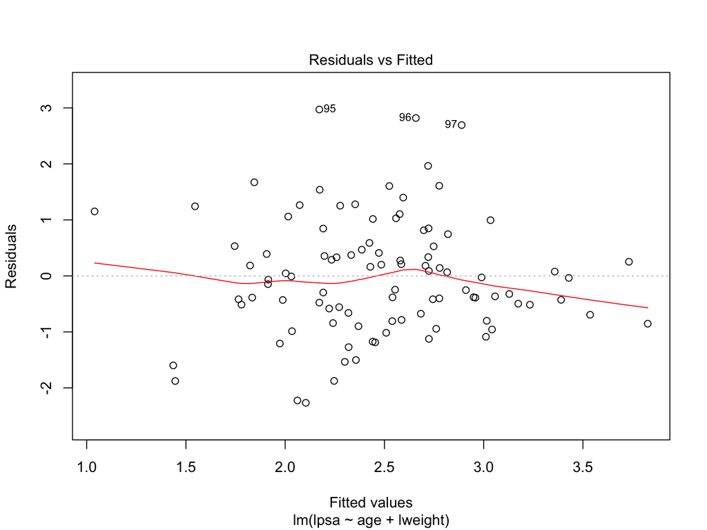

```r
plot(lm_prostate, 1)
```

# QQ-plot

- QQ-plot is what’s called a quantile-quantile plot.
- Comparing two probability distributions by plotting their quantiles against each other.
  - Quantile of x: percentage of data that are smaller than x.
- A point (x, y) in QQ-plot:
  - x: value at the rth quantile of the first distribution.
  - y: value at the rth quantile of the second distribution.
  - rth: same quantile.

# QQ-plot 0

- Normal distribution from sampling vs theoritical normal distribution
  - a: $N(0,1)$
  - b: rnorm(1000)

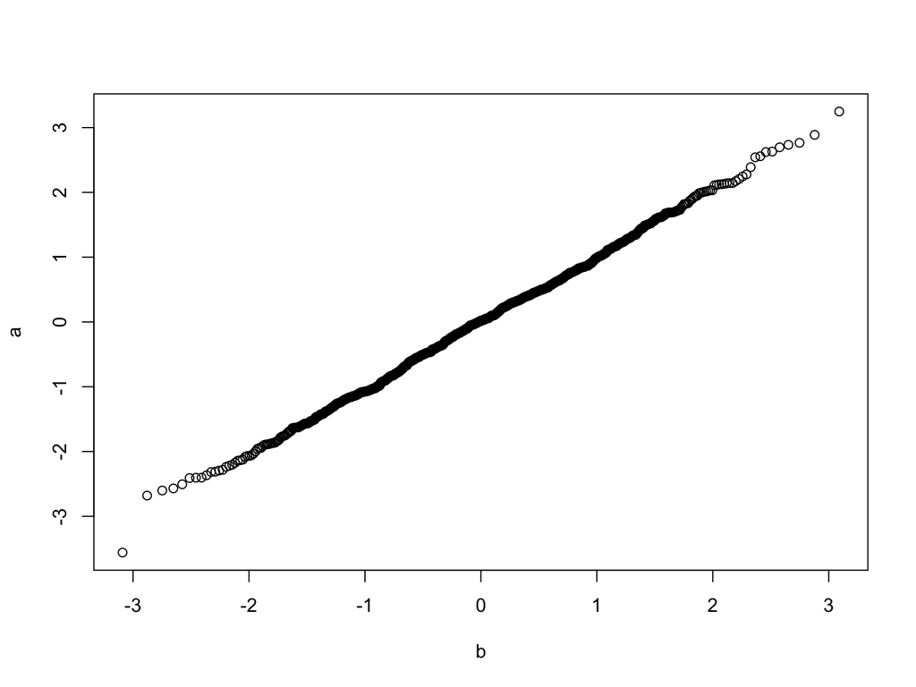

```r
set.seed(32611)
a0 <- rnorm(1000)
a <- sort(a0)
quantile_a <- seq_along(a) / (length(a) + 1) ## quantiles of the data from sampling
b <- qnorm(quantile_a)  ## data from the therotical normal distribution at the same quantiles

plot(b, a) ## QQ-plot
```

- A straight line indicates two distributions agree with each other

# QQ-plot 1

- qqnorm: QQ-plot for a sampling distribution against the theoritical standard normal distribution.

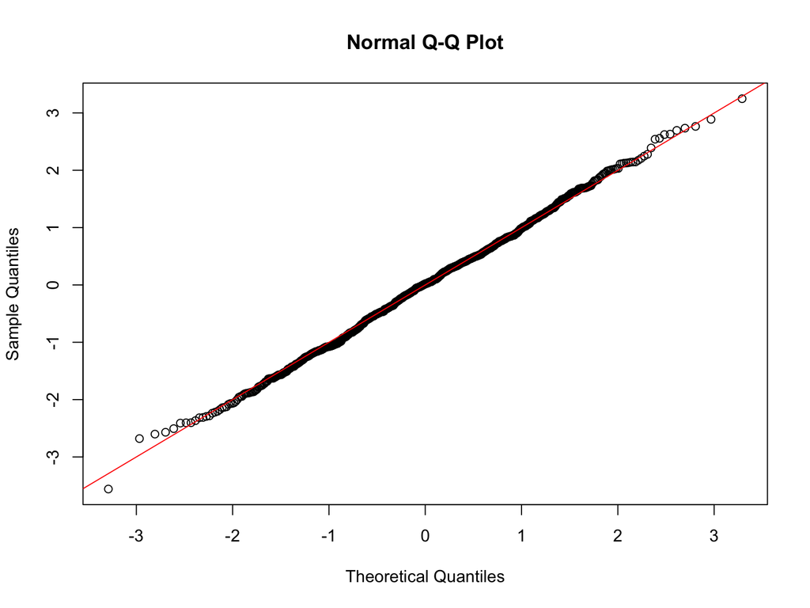

```r
set.seed(32611)
a <- rnorm(1000)
qqnorm(a)
abline(a = 0,b = 1, col=2) ## x = y line
```

- In this example, a straight line (x=y) for QQ-plot shows the sampling distribution is likely to be $N(0,1)$).

# QQ-plot 2

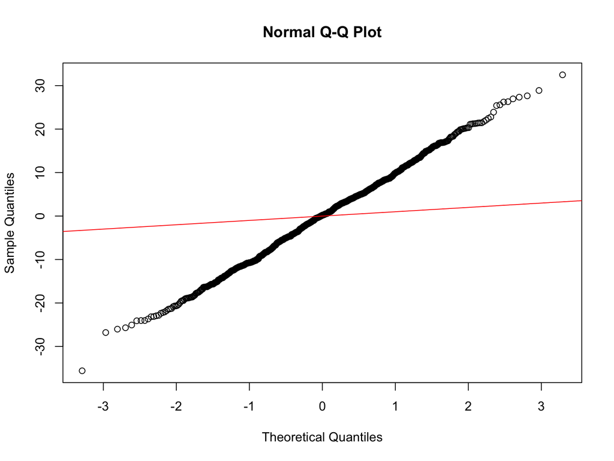

```r
set.seed(32611)
qqnorm(rnorm(1000, sd=10))
abline(a = 0,b = 1, col=2) ## x = y line
```

- A straight line for QQ-plot shows the sampling distribution is likely to be normally distributed.
- If the slope is different from 1, then this is not a standard normal distribution, but still a normal distribution.

# QQ-plot 3

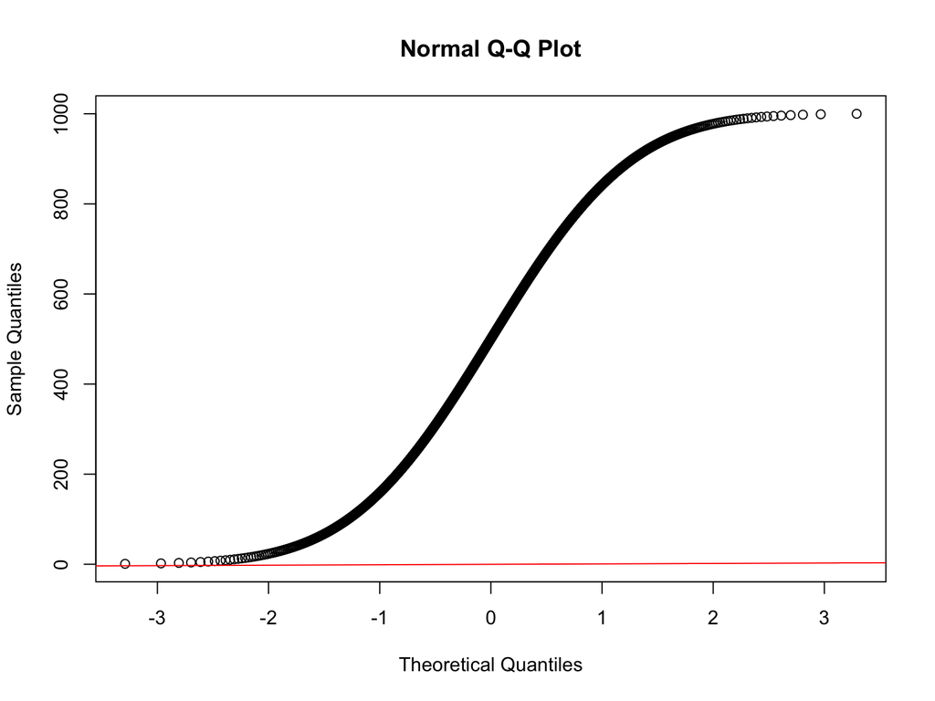

```r
set.seed(32611)
qqnorm(1:1000)
abline(a = 0,b = 1, col=2) ## x = y line
```

# QQ-plot 4

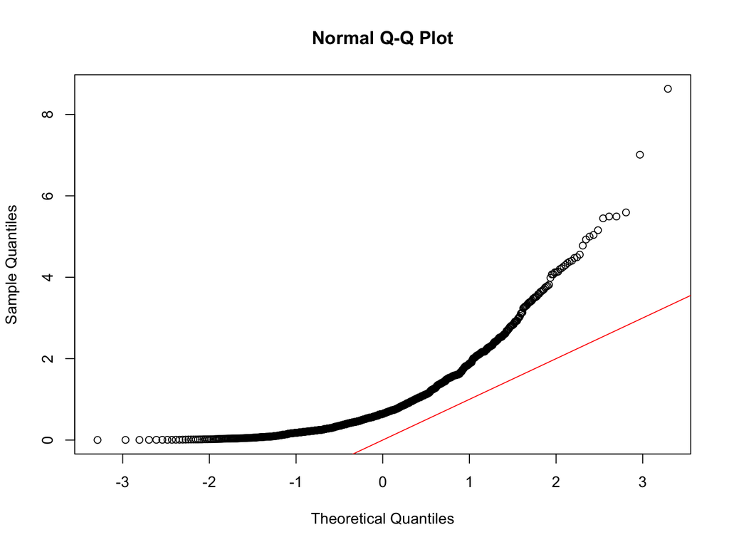

```r
set.seed(32611)
qqnorm(rexp(1000))
abline(a = 0,b = 1, col=2) ## x = y line
```

# Prostate cancer example

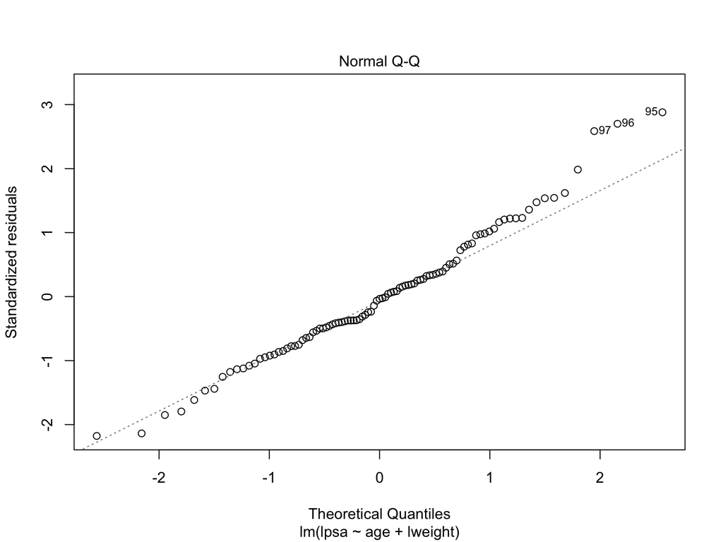

```r
lm_prostate <- lm(lpsa ~ age + lweight, data = prostate)
plot(lm_prostate, 2)
```

# Formal normality test

```r
set.seed(32611)
shapiro.test(rnorm(1000))
```

```
##
##  Shapiro-Wilk normality test
##
## data:  rnorm(1000)
## W = 0.99873, p-value = 0.7059
```

```r
shapiro.test(1:1000)
```

```
##
##  Shapiro-Wilk normality test
##
## data:  1:1000
## W = 0.95481, p-value < 2.2e-16
```

```r
shapiro.test(residuals(lm_prostate))
```

```
##
##  Shapiro-Wilk normality test
##
## data:  residuals(lm_prostate)
## W = 0.98133, p-value = 0.1836
```

# Unusual and Influential Data

- Outlier: An observation with large residual.
  - An outlier may indicate a sample peculiarity or may indicate a data entry error or other problem.
- Leverage point: An observation with an extreme value on a predictor variable.
  - Leverage is a measure of how far an independent variable deviates from its mean.
  - These leverage points can have an effect on the estimate of regression coefficients.
- Influential point: Influence can be thought of as the product of leverage and outlierness.
  - Can be measured by Cook’s distance.
  - Removing the observation substantially changes the estimate of coefficients.
  - Criteria: Cook’s D > 4/n

# Outliers

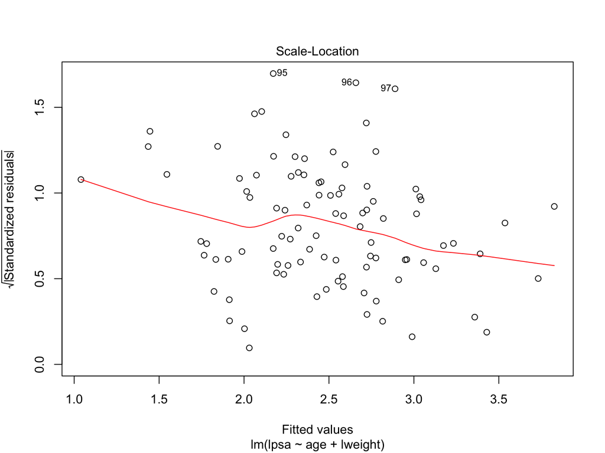

```r
plot(lm_prostate, 3)
```

# Leverage

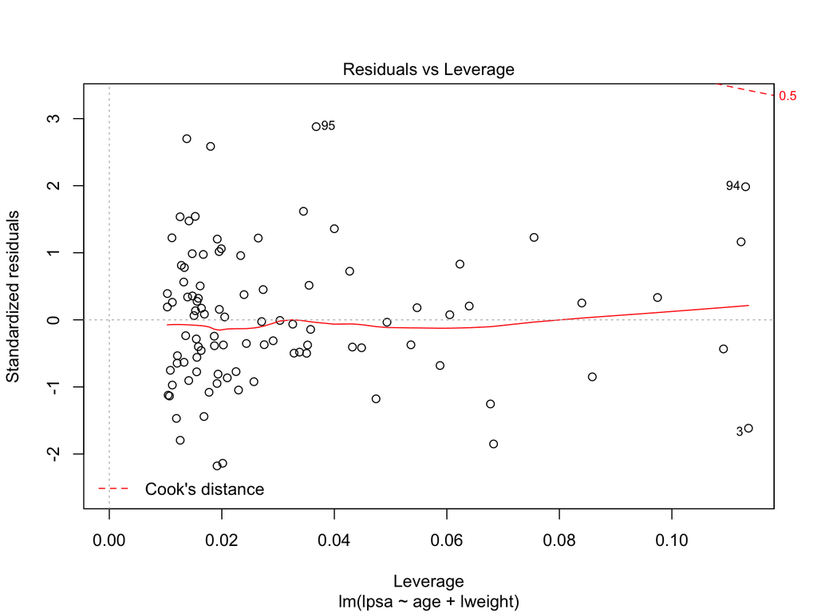

```r
plot(lm_prostate, 5)
```

# influential points: Cook’s distance

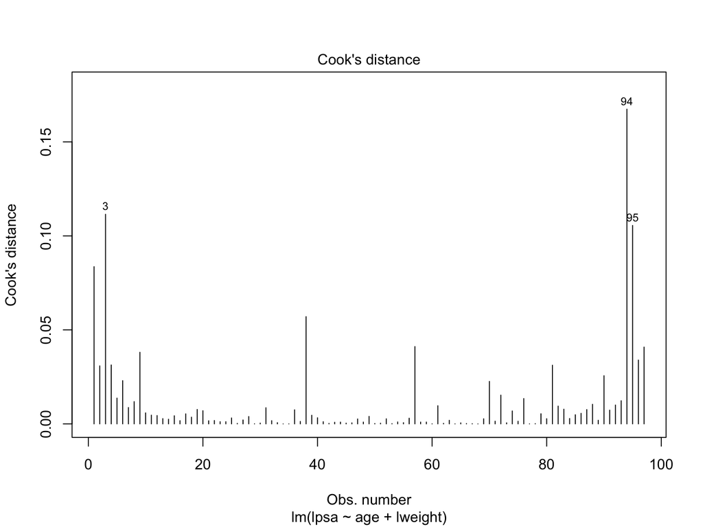

```r
plot(lm_prostate, 4)
```

# Fit a linear regression model with all variables

```r
lm_all <- lm(lpsa ~ ., data=prostate) ## . Rest of all the other vaiables.
summary(lm_all)
```

```
##
## Call:
## lm(formula = lpsa ~ ., data = prostate)
##
## Residuals:
##      Min       1Q   Median       3Q      Max
## -1.76644 -0.35510 -0.00328  0.38087  1.55770
##
## Coefficients:
##              Estimate Std. Error t value Pr(>|t|)
## (Intercept)  0.181561   1.320568   0.137  0.89096
## lcavol       0.564341   0.087833   6.425 6.55e-09 ***
## lweight      0.622020   0.200897   3.096  0.00263 **
## age         -0.021248   0.011084  -1.917  0.05848 .
## lbph         0.096713   0.057913   1.670  0.09848 .
## svi          0.761673   0.241176   3.158  0.00218 **
## lcp         -0.106051   0.089868  -1.180  0.24115
## gleason      0.049228   0.155341   0.317  0.75207
## pgg45        0.004458   0.004365   1.021  0.31000
## ---
## Signif. codes:  0 '***' 0.001 '**' 0.01 '*' 0.05 '.' 0.1 ' ' 1
##
## Residual standard error: 0.6995 on 88 degrees of freedom
## Multiple R-squared:  0.6634, Adjusted R-squared:  0.6328
## F-statistic: 21.68 on 8 and 88 DF,  p-value: < 2.2e-16
```

# Variance inflation factor (VIF)

- collinearity: if two predictors are highly correlated (very similar to each other)
- Variance inflation factor can be used to detect collinearity
- VIF > 10 indicates severe collinearity issue.

```r
lm_all <- lm(lpsa ~ ., data=prostate) ## . Rest of all the other vaiables.
car::vif(lm_all)
```

```
##   lcavol  lweight      age     lbph      svi      lcp  gleason    pgg45
## 2.102650 1.453325 1.336099 1.385040 1.955928 3.097954 2.468891 2.974075
```

# Model selection

- With many predictors, what combination of predictors provide the best model?
  - AIC, BIC criteria
  - forward selection and backward selection

# AIC, BIC

- AIC: Akaike information criterion
- $AIC = 2k - 2 \log ( {\hat{L}} )$
  - k: number of parameters.
  - $\hat{L}$: likelihood given the coefficient estimates

```r
AIC(lm_all)
```

```
## [1] 216.4952
```

- BIC: Bayesian information criterion, (though it has noting to do with Bayesian)
- $BIC = log(n)k - 2 \log ( {\hat{L}} )$

```r
BIC(lm_all)
```

```
## [1] 242.2423
```

- Minimize AIC or BIC

# backward selection

- step() function can perform forward selection, backward selection or both.
  - other direction options: c(“both”, “backward”, “forward”)

```r
step(lm(lpsa ~ ., data=prostate)) ## default is backward selection
```

```
## Start:  AIC=-60.78
## lpsa ~ lcavol + lweight + age + lbph + svi + lcp + gleason +
##     pgg45
##
##           Df Sum of Sq    RSS     AIC
## - gleason  1    0.0491 43.108 -62.668
## - pgg45    1    0.5102 43.569 -61.636
## - lcp      1    0.6814 43.740 -61.256
## <none>                 43.058 -60.779
## - lbph     1    1.3646 44.423 -59.753
## - age      1    1.7981 44.857 -58.810
## - lweight  1    4.6907 47.749 -52.749
## - svi      1    4.8803 47.939 -52.364
## - lcavol   1   20.1994 63.258 -25.467
##
## Step:  AIC=-62.67
## lpsa ~ lcavol + lweight + age + lbph + svi + lcp + pgg45
##
##           Df Sum of Sq    RSS     AIC
## - lcp      1    0.6684 43.776 -63.176
## <none>                 43.108 -62.668
## - pgg45    1    1.1987 44.306 -62.008
## - lbph     1    1.3844 44.492 -61.602
## - age      1    1.7579 44.865 -60.791
## - lweight  1    4.6429 47.751 -54.746
## - svi      1    4.8333 47.941 -54.360
## - lcavol   1   21.3191 64.427 -25.691
##
## Step:  AIC=-63.18
## lpsa ~ lcavol + lweight + age + lbph + svi + pgg45
##
##           Df Sum of Sq    RSS     AIC
## - pgg45    1    0.6607 44.437 -63.723
## <none>                 43.776 -63.176
## - lbph     1    1.3329 45.109 -62.266
## - age      1    1.4878 45.264 -61.934
## - svi      1    4.1766 47.953 -56.336
## - lweight  1    4.6553 48.431 -55.373
## - lcavol   1   22.7555 66.531 -24.572
##
## Step:  AIC=-63.72
## lpsa ~ lcavol + lweight + age + lbph + svi
##
##           Df Sum of Sq    RSS     AIC
## <none>                 44.437 -63.723
## - age      1    1.1588 45.595 -63.226
## - lbph     1    1.5087 45.945 -62.484
## - lweight  1    4.3140 48.751 -56.735
## - svi      1    5.8509 50.288 -53.724
## - lcavol   1   25.9427 70.379 -21.119
```

```
##
## Call:
## lm(formula = lpsa ~ lcavol + lweight + age + lbph + svi, data = prostate)
##
## Coefficients:
## (Intercept)       lcavol      lweight          age         lbph
##     0.49473      0.54400      0.58821     -0.01644      0.10122
##         svi
##     0.71490
```

- You may notice that AIC from step() and AIC() are different
- AIC/BIC can be different for different methods up to a constant.

```r
stepDetails <- step(lm(lpsa ~ ., data=prostate), trace=0)$anova
stepDetails$AIC[2] - stepDetails$AIC[1]
```

```
## [1] -1.889365
```

```r
AIC(lm(lpsa ~ . - gleason, data=prostate)) - AIC(lm(lpsa ~ ., data=prostate))
```

```
## [1] -1.889365
```

# non-linear predictor (1)

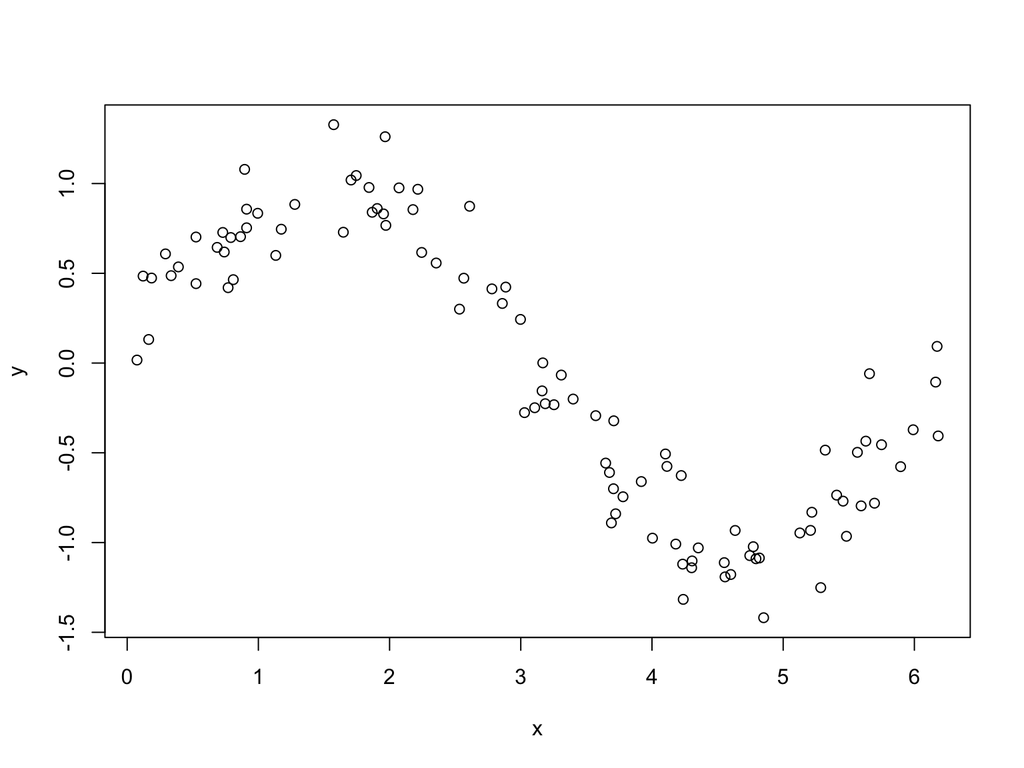

```r
library(minpack.lm)

## simulate data from sin function
set.seed(32611)
n <- 100
x <- runif(n,0,2*pi)
y <- sin(x) + rnorm(n,sd=0.2)
plot(x,y)
```

# fit $y = A \sin(x + B) + C$

```r
getPred <- function(parS, xx) {
    ## parS: parameter list
    ## xx: x values (predictors)
        parS$A * sin(xx + parS$B) + parS$C
    }

residFun <- function(p, observed, xx) observed - getPred(p,xx)

parStart <- list(A=1, B=3, C=0)
nls.out <- nls.lm(par=parStart, fn = residFun, observed = y,    xx = x)
nls.out
```

```
## Nonlinear regression via the Levenberg-Marquardt algorithm
## parameter estimates: -1.03727642432862, 3.18141544265264, -0.0260329085154092
## residual sum-of-squares: 3.783
## reason terminated: Conditions for `info = 1' and `info = 2' both hold.
```

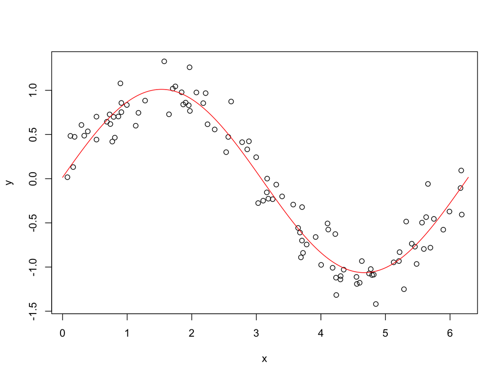

```r
aseq <- seq(0,2*pi,length.out = 1000)
plot(x,y)
with(nls.out$par, lines(aseq, A*sin(aseq + B) + C, col=2))
```

# non-linear predictor (2)

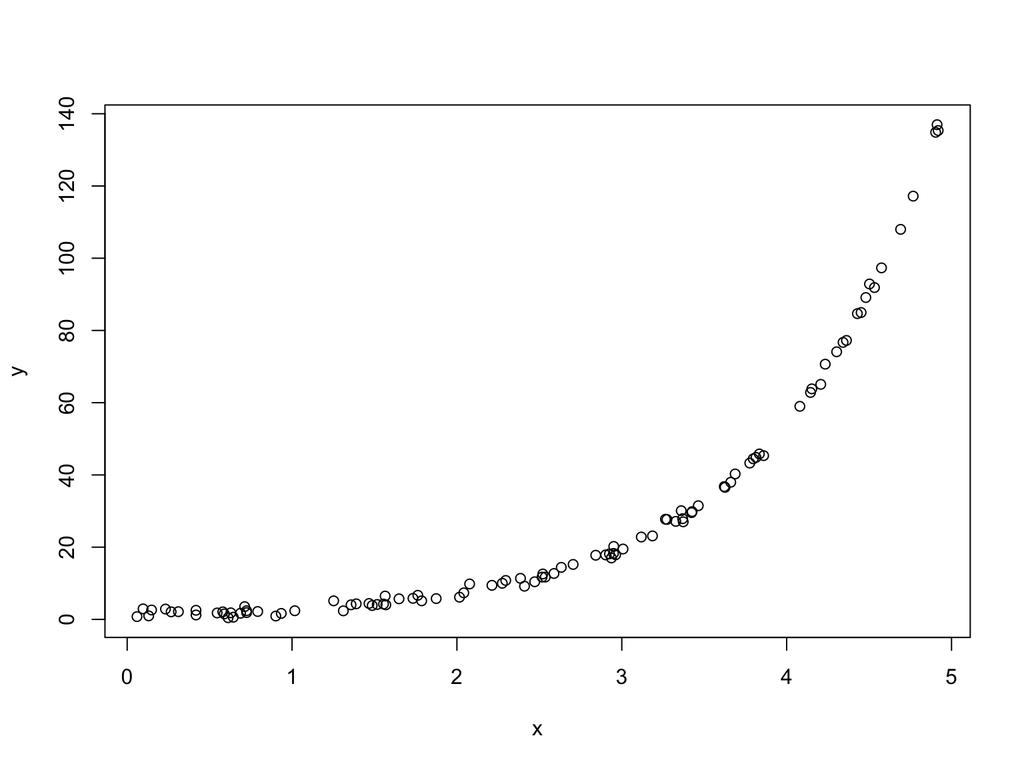

```r
set.seed(32611)
n <- 100;
x <- runif(n,0,5)
y <- exp(x) + rnorm(n,sd=1)
plot(x,y)
```

# fit $y = a \times \exp(bx)$

```r
getPred <- function(parS, xx) {
        parS$A * exp(parS$B * xx)
    }

residFun <- function(p, observed, xx) observed - getPred(p,xx)

parStart <- list(A=3, B=3)
nls.out <- nls.lm(par=parStart, fn = residFun, observed = y,    xx = x)
nls.out
```

```
## Nonlinear regression via the Levenberg-Marquardt algorithm
## parameter estimates: 0.963577134214599, 1.00769428203048
## residual sum-of-squares: 95.74
## reason terminated: Conditions for `info = 1' and `info = 2' both hold.
```

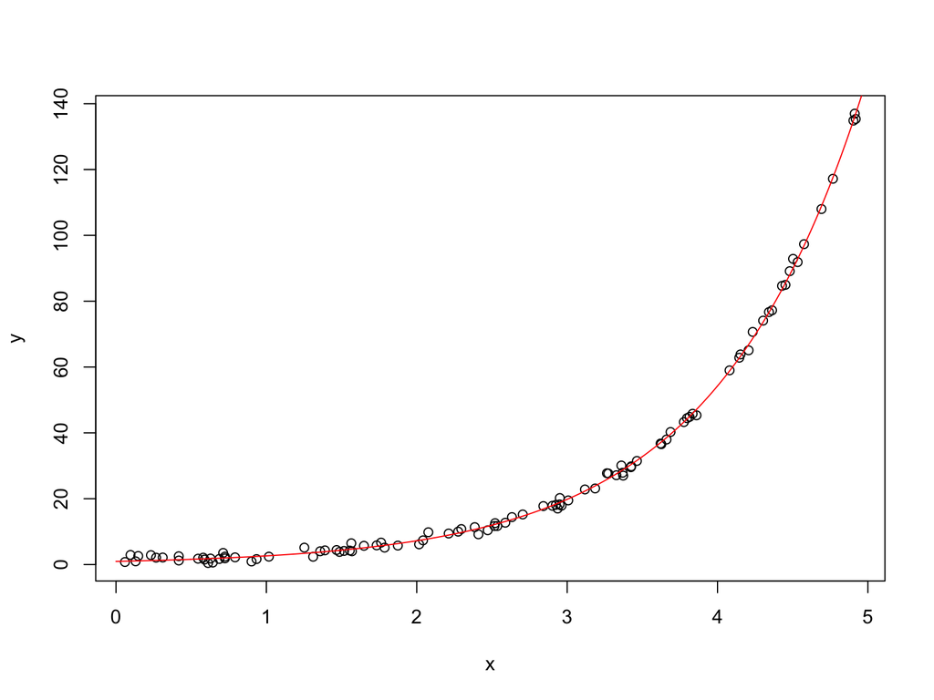

```r
aseq <- seq(0,5,length.out = 1000)
plot(x,y)
with(nls.out$par, lines(aseq, A*exp(B*aseq), col=2))
```

# Splines

- Non-parametric approach to fit the curve (usually dimension $d=1$).
- These basis functions are splines.
- A kth order spline is a piecewise polynomial function of degree k, that is continuous and has continuous derivatives of orders $1, \ldots, k-1$, at its knot points.

# Splines motivating example

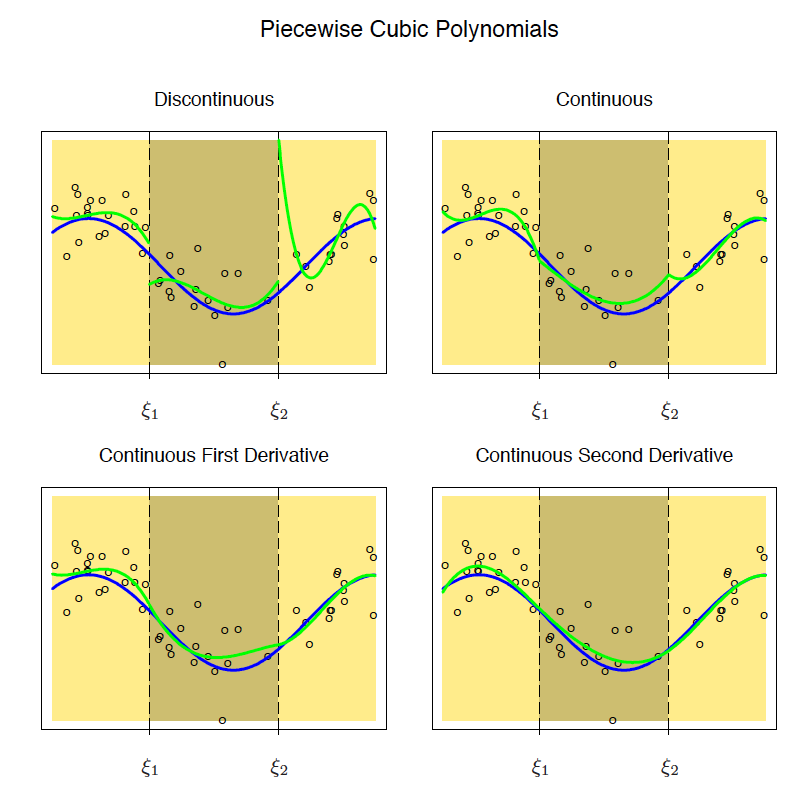

continuity at the knots, from book the “element of statistical leaning”

# Splines basis

How to parametrize the set of splines with knots at $t_1, \ldots, t_m$?

- truncated power basis:
  - $g_1(x) = 1$, $g_2(x) = x$, …, $g_{k+1}(x) = x^k$
  - $g_{k+1+j}(x) = (x - t_j)^k_+$, $j = 1, \ldots, m$
  - $(\cdot)_+ = \max(0, \cdot)$
- B-spline basis https://en.wikipedia.org/wiki/B-spline

# Splines types

- Regression splines
- Natural splines
- Smoothing splines

# Regression splines

- Given input $x_1, \ldots, x_n$ and output $y_1, \ldots, y_n$, we consider to fit function $f$ with $k^{th}$ order splines with given knots at $t_1, \ldots, t_m$
  $$f(x) = \sum_{j=1}^{m+k+1} \beta_j g_j(x),$$
  where $\beta_j, 1\le j \le m+k+1$ are coefficients and $g_j, 1\le j \le m+k+1$ are basis functions for order $k$ spline on the knots $t_1, \ldots, t_m$ (e.g. truncated power basis or B-spline basis).
- define $G \in \mathbb{R}^{n \times (m+k+1)}$, where $G_{ij} = g_j(x_i)$.
- The solution coefficients $\hat{\beta} = (\hat{\beta}_1, \ldots, \hat{\beta}_{m+k+1})$

$$\hat{\beta} = \arg \min_{\beta \in \mathbb{R}^{m+k+1}} \|y - G\beta\|_2^2$$

- We know the solution is $\hat{\beta} (G^\top G)^{-1} G^\top y$

# Natural splines

- The problem with regression splines is that the estimates have high variance at the boundaries of the input domain.
- A solution is to force the piecewise polynomial function have lower degree at the boundary.
  - $f$ is a polynomial of degree $k$ on each of $[t_1, t_2], \ldots, [t_{m-1}, t_m]$
  - $f$ is a polynomial of degree $(k-1)/2$ on each of $(-\infty, t_1]$ and $[t_m, \infty)$

# Smoothing splines

- placing knots at all inputs $x_1, \ldots, x_n$, circumvent knot selection problem.

$$\hat{f} = \arg\min_f \sum_{i=1}^n (y_i - f(x_i))^2 + \lambda \int_a^b (f^{((k+1)/2)})^2 dx$$

[output not shown]

- When $k = 3$, this is the cubic smoothing splines, which is very commonly used.

$$\hat{f} = \arg\min_f \sum_{i=1}^n (y_i - f(x_i))^2 + \lambda \int_a^b (f''(x))^2 dx$$

- Remarkably, it happens that the minimizer of general smoothing spline is a natural $k^{th}$ order spline with knots at input points $x_1, \ldots, x_n$.

# cubic smoothing spline in R (data points)

- smooth.spline()

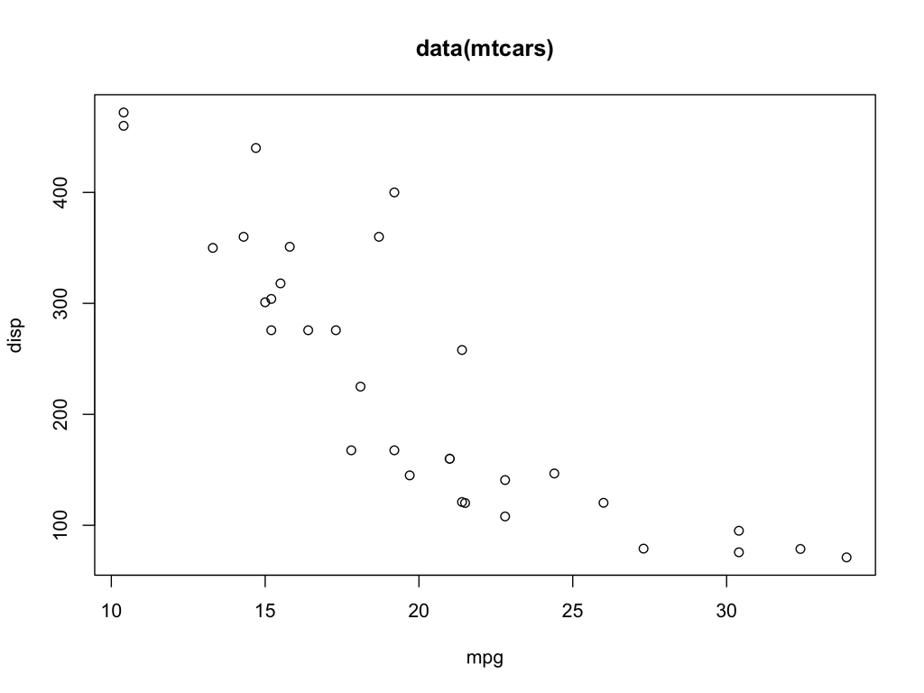

```r
plot(disp ~ mpg, data = mtcars, main = "data(mtcars)")
```

# cubic smoothing spline in R

```r
plot(disp ~ mpg, data = mtcars, main = "data(mtcars)  &  smoothing splines")
cars.spl <- with(mtcars, smooth.spline(mpg, disp))
cars.spl
```

```
## Call:
## smooth.spline(x = mpg, y = disp)
##
## Smoothing Parameter  spar= 0.9009065  lambda= 0.02109193 (11 iterations)
## Equivalent Degrees of Freedom (Df): 3.211475
## Penalized Criterion (RSS): 61580.33
## GCV: 3828.877
```

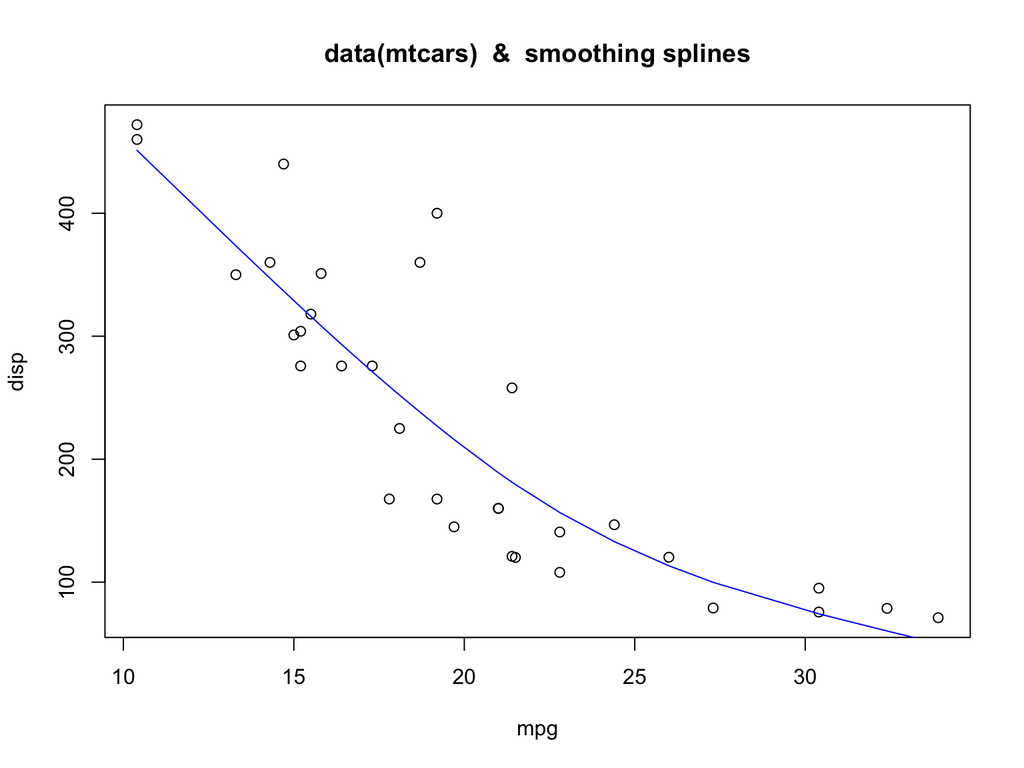

```r
lines(cars.spl, col = "blue")
```